# Sample Size for Subgroup Detection

Asymptotic Approximations for ForestSearch Power Analysis

Author

ForestSearch Development Team

Published

January 21, 2026

# 1 Introduction

1. **True hazard ratio (θ)** in the subgroup
2. **Subgroup sample size (n<sub>sg</sub>)**
3. **Censoring proportion (p<sub>C</sub>)**
4. **Detection threshold (HR<sub>threshold</sub>)**
5. **Consistency threshold (HR<sub>consistency</sub>)**

## 1.1 Asymptotic Approximation

Under large-sample theory, the log hazard ratio estimator follows approximately:

$$\log(\widehat{HR}) \sim N\left(\log(\theta), \frac{4}{d_0} + \frac{4}{d_1}\right)$$

where $d_0$ and $d_1$ are the number of events in control and treatment arms. For balanced designs with total events $d = n_{sg}(1 - p_C)$:

ForestSearch uses split-sample consistency, requiring both halves to exceed thresholds. The detection probability integrates over the joint distribution of the two split-half estimators.

# 2 Single Scenario Analysis

Let’s start with a concrete example: detecting a subgroup with HR = 1.5.

```r
# Define scenario parameters
scenario <- list(
 theta = 1.5,           # True HR in subgroup
  n_sg = 60,             # Subgroup sample size
  prop_cens = 0.30,      # 30% censoring
  hr_threshold = 1.25,   # Detection threshold
  hr_consistency = 1.0   # Consistency threshold
)

# Compute detection probability
prob_detect <- compute_detection_probability(
  theta = scenario$theta,
  n_sg = scenario$n_sg,
  prop_cens = scenario$prop_cens,
  hr_threshold = scenario$hr_threshold,
  hr_consistency = scenario$hr_consistency
)

cat("=== Single Scenario Analysis ===\n")
```

```
=== Single Scenario Analysis ===
```

```r
cat(sprintf("True HR (θ):          %.2f\n", scenario$theta))
```

```
True HR (θ):          1.50
```

```r
cat(sprintf("Subgroup size:        %d\n", scenario$n_sg))
```

```
Subgroup size:        60
```

```r
cat(sprintf("Censoring:            %.0f%%\n", 100 * scenario$prop_cens))
```

```
Censoring:            30%
```

```r
cat(sprintf("Events expected:      %.0f\n", scenario$n_sg * (1 - scenario$prop_cens)))
```

```
Events expected:      42
```

```r
cat(sprintf("HR threshold:         %.2f\n", scenario$hr_threshold))
```

```
HR threshold:         1.25
```

```r
cat(sprintf("\nP(Detect subgroup):   %.3f (%.1f%%)\n", prob_detect, 100 * prob_detect))
```

```
P(Detect subgroup):   0.622 (62.2%)
```

With 60 subjects in the subgroup, 30% censoring, and a true HR of 1.5, we have approximately 62% probability of detecting the subgroup using ForestSearch’s consistency criteria.

# 3 Detection Probability Curves

## 3.1 Effect of True Hazard Ratio

The detection probability increases with the true effect size. Let’s visualize this relationship:

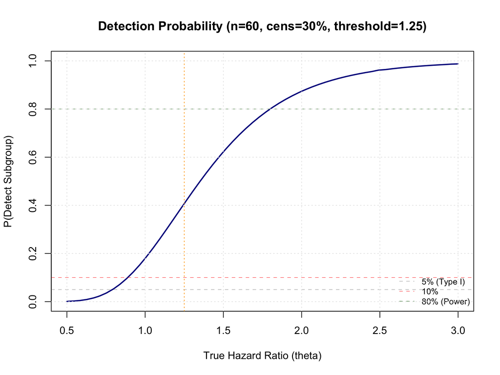

Detection probability as a function of true hazard ratio

```r
# Generate detection curve
curve_n60 <- generate_detection_curve(
  theta_range = c(0.5, 3.0),
  n_points = 60,
  n_sg = 60,
  prop_cens = 0.30,
  hr_threshold = 1.25,
  verbose = FALSE
)

# Plot with base R
plot_detection_curve(curve_n60)
```

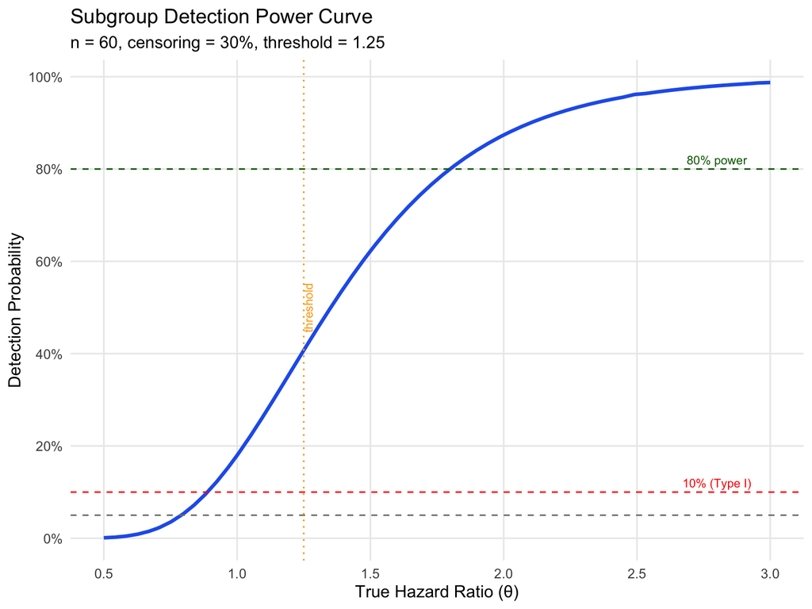

Detection probability curve (ggplot2 version)

```r
# ggplot2 version for more customization
ggplot(curve_n60, aes(x = theta, y = probability)) +
  geom_line(linewidth = 1.2, color = "#2563eb") +
  geom_hline(yintercept = c(0.05, 0.10, 0.80),
             linetype = "dashed", color = c("gray50", "red", "darkgreen"),
             linewidth = 0.5) +
  geom_vline(xintercept = 1.25, linetype = "dotted", color = "orange") +
  annotate("text", x = 2.8, y = 0.82, label = "80% power", size = 3, color = "darkgreen") +
  annotate("text", x = 2.8, y = 0.12, label = "10% (Type I)", size = 3, color = "red") +
  annotate("text", x = 1.30, y = 0.50, label = "threshold", size = 3,
           color = "orange", angle = 90, vjust = -0.5) +
  scale_x_continuous(breaks = seq(0.5, 3.0, 0.5)) +
  scale_y_continuous(breaks = seq(0, 1, 0.2), labels = scales::percent) +
  labs(
    x = "True Hazard Ratio (θ)",
    y = "Detection Probability",
    title = "Subgroup Detection Power Curve",
    subtitle = sprintf("n = %d, censoring = %.0f%%, threshold = %.2f",
                       60, 30, 1.25)
  ) +
  theme(panel.grid.minor = element_blank())
```

## 3.2 Effect of Sample Size

Sample size has a major impact on detection probability:

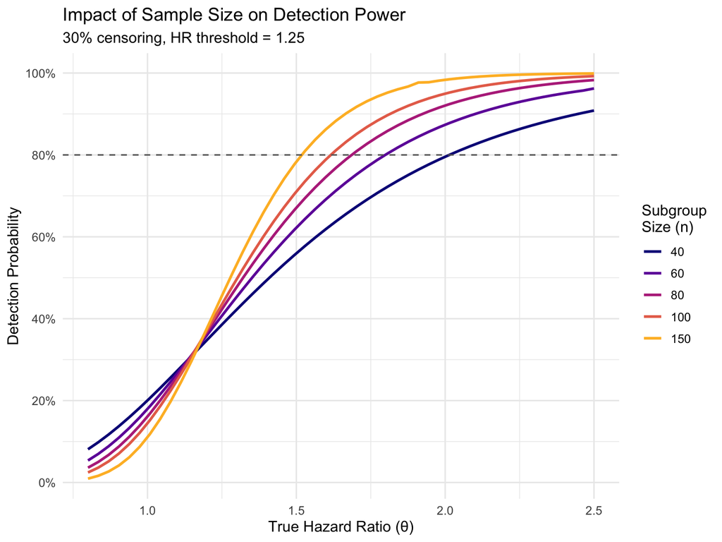

Detection curves for different subgroup sample sizes

```r
# Compare across sample sizes
comparison_n <- compare_detection_curves(
 n_sg_values = c(40, 60, 80, 100, 150),
  prop_cens = 0.30,
  hr_threshold = 1.25,
  theta_range = c(0.8, 2.5),
  n_points = 50,
  verbose = FALSE
)

# Plot comparison
ggplot(comparison_n, aes(x = theta, y = probability, color = factor(n_sg))) +
  geom_line(linewidth = 1) +
  geom_hline(yintercept = 0.80, linetype = "dashed", color = "gray40") +
  scale_color_viridis_d(option = "plasma", end = 0.85) +
  scale_y_continuous(breaks = seq(0, 1, 0.2), labels = scales::percent) +
  labs(
    x = "True Hazard Ratio (θ)",
    y = "Detection Probability",
    color = "Subgroup\nSize (n)",
    title = "Impact of Sample Size on Detection Power",
    subtitle = "30% censoring, HR threshold = 1.25"
  ) +
  theme(legend.position = "right")
```

```r
# Find HR needed for 80% power at each sample size
power_80_hr <- sapply(c(40, 60, 80, 100, 150, 200), function(n) {
  curve <- generate_detection_curve(
    theta_range = c(1.0, 3.0),
    n_points = 100,
    n_sg = n,
    prop_cens = 0.30,
    hr_threshold = 1.25,
    verbose = FALSE
  )
  # Find HR where probability crosses 0.80
  idx <- which.min(abs(curve$probability - 0.80))
  curve$theta[idx]
})

hr_table <- data.frame(
  `Subgroup Size` = c(40, 60, 80, 100, 150, 200),
  `Events (expected)` = round(c(40, 60, 80, 100, 150, 200) * 0.70),
  `HR for 80% Power` = round(power_80_hr, 2)
)

knitr::kable(hr_table, align = "c")
```

HR required for 80% detection probability by sample size

| Subgroup.Size | Events..expected. | HR.for.80..Power |
| --- | --- | --- |
| 40 | 28 | 2.01 |
| 60 | 42 | 1.81 |
| 80 | 56 | 1.69 |
| 100 | 70 | 1.61 |
| 150 | 105 | 1.53 |
| 200 | 140 | 1.46 |

# 4 Effect of Censoring

Censoring reduces the effective information (events) available for HR estimation:

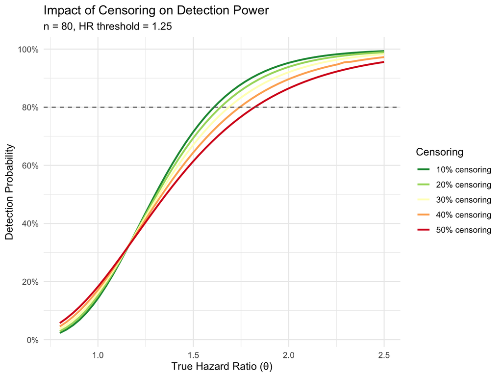

Impact of censoring on detection probability

```r
# Compare censoring rates
cens_rates <- c(0.10, 0.20, 0.30, 0.40, 0.50)
curves_cens <- lapply(cens_rates, function(pc) {
  curve <- generate_detection_curve(
    theta_range = c(0.8, 2.5),
    n_points = 50,
    n_sg = 80,
    prop_cens = pc,
    hr_threshold = 1.25,
    verbose = FALSE
  )
  curve$cens_label <- sprintf("%.0f%% censoring", 100 * pc)
  curve
})
curves_cens_df <- do.call(rbind, curves_cens)

ggplot(curves_cens_df, aes(x = theta, y = probability, color = cens_label)) +
  geom_line(linewidth = 1) +
  geom_hline(yintercept = 0.80, linetype = "dashed", color = "gray40") +
  scale_color_brewer(palette = "RdYlGn", direction = -1) +
  scale_y_continuous(breaks = seq(0, 1, 0.2), labels = scales::percent) +
  labs(
    x = "True Hazard Ratio (θ)",
    y = "Detection Probability",
    color = "Censoring",
    title = "Impact of Censoring on Detection Power",
    subtitle = "n = 80, HR threshold = 1.25"
  )
```

**Rule of thumb:** For every 10% increase in censoring, you need approximately 15-20% more subjects to maintain the same detection power.

# 5 Required Sample Size Calculations

## 5.1 Finding Minimum Sample Size

Given a target power and expected effect size, what subgroup size do we need?

```r
# Example: 80% power to detect HR = 1.5
ss_result <- find_required_sample_size(
  theta = 1.5,
  target_power = 0.80,
  prop_cens = 0.30,
  hr_threshold = 1.25,
  verbose = TRUE
)

cat("\n=== Sample Size Result ===\n")
```

```
=== Sample Size Result ===
```

```r
cat(sprintf("Required subgroup size: %d\n", ss_result$n_sg_required))
```

```
Required subgroup size: 165
```

```r
cat(sprintf("Achieved power: %.3f\n", ss_result$achieved_power))
```

```
Achieved power: 0.800
```

```r
cat(sprintf("Required events: %.0f\n", ss_result$n_sg_required * (1 - 0.30)))
```

```
Required events: 115
```

## 5.2 Sample Size Table for Multiple Scenarios

For study planning, it’s useful to have a comprehensive table:

```r
# Create comprehensive sample size table
ss_table <- create_sample_size_table(
  theta_values = c(1.3, 1.5, 1.75, 2.0, 2.5),
  prop_cens_values = c(0.20, 0.30, 0.40),
  target_power = 0.80,
  hr_threshold = 1.25,
  verbose = FALSE
)

# Reshape for display
ss_wide <- dcast(
  as.data.table(ss_table),
  theta ~ prop_cens,
  value.var = "n_required"
)
names(ss_wide) <- c("True HR", "20% Cens", "30% Cens", "40% Cens")

knitr::kable(
  ss_wide,
  caption = "Required subgroup n for 80% power (HR threshold = 1.25)",
  align = "c"
)
```

Required subgroup sample sizes for 80% detection power

| True HR | 20% Cens | 30% Cens | 40% Cens |
| --- | --- | --- | --- |
| 1.30 | NA | NA | NA |
| 1.50 | 145 | 165 | 193 |
| 1.75 | 59 | 68 | 79 |
| 2.00 | 36 | 41 | 48 |
| 2.50 | 20 | 23 | 27 |

```r
# Convert to required events
ss_events <- ss_table
ss_events$events_required <- round(ss_events$n_required * (1 - ss_events$prop_cens))

events_wide <- dcast(
  as.data.table(ss_events),
  theta ~ prop_cens,
  value.var = "events_required"
)
names(events_wide) <- c("True HR", "20% Cens", "30% Cens", "40% Cens")

knitr::kable(
  events_wide,
  caption = "Required events in subgroup for 80% power",
  align = "c"
)
```

Required events for 80% detection power

| True HR | 20% Cens | 30% Cens | 40% Cens |
| --- | --- | --- | --- |
| 1.30 | NA | NA | NA |
| 1.50 | 116 | 115 | 116 |
| 1.75 | 47 | 48 | 47 |
| 2.00 | 29 | 29 | 29 |
| 2.50 | 16 | 16 | 16 |

# 6 Impact of Detection Threshold

The choice of HR threshold affects the trade-off between sensitivity and specificity:

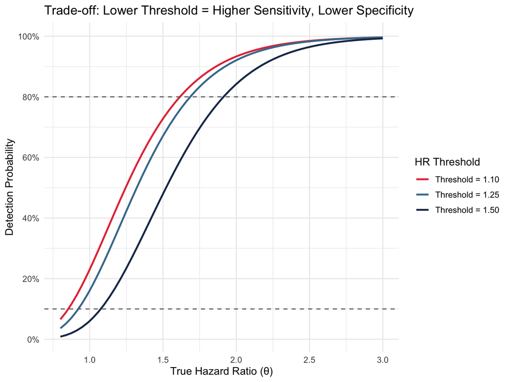

Detection curves for different HR thresholds

```r
# Compare thresholds
thresholds <- c(1.10, 1.25, 1.50)
curves_thresh <- lapply(thresholds, function(thr) {
  curve <- generate_detection_curve(
    theta_range = c(0.8, 3.0),
    n_points = 60,
    n_sg = 80,
    prop_cens = 0.30,
    hr_threshold = thr,
    verbose = FALSE
  )
  curve$threshold_label <- sprintf("Threshold = %.2f", thr)
  curve
})
curves_thresh_df <- do.call(rbind, curves_thresh)

ggplot(curves_thresh_df, aes(x = theta, y = probability, color = threshold_label)) +
  geom_line(linewidth = 1) +
  geom_hline(yintercept = c(0.10, 0.80), linetype = "dashed", color = "gray40") +
  scale_color_manual(values = c("#e63946", "#457b9d", "#1d3557")) +
  scale_y_continuous(breaks = seq(0, 1, 0.2), labels = scales::percent) +
  labs(
    x = "True Hazard Ratio (θ)",
    y = "Detection Probability",
    color = "HR Threshold",
    title = "Trade-off: Lower Threshold = Higher Sensitivity, Lower Specificity"
  )
```

**Observations:**

- **Lower threshold (1.10):** Detects smaller effects but higher false positive rate
- **Higher threshold (1.50):** More conservative, requires larger true effects
- **Standard threshold (1.25):** Balanced approach used in ForestSearch

# 7 Planning a Subgroup Analysis

## 7.1 Example: Planning for Expected Subgroup Prevalence

Suppose you’re designing a trial with:

- Total sample size: N = 500
- Expected subgroup prevalence: 20%
- Expected censoring: 30%
- Minimum clinically meaningful HR: 1.5

```r
# Trial planning parameters
N_total <- 500
prevalence <- 0.20
prop_cens <- 0.30
target_hr <- 1.5

# Expected subgroup size
n_sg_expected <- N_total * prevalence

cat("=== Trial Planning Analysis ===\n")
```

```
=== Trial Planning Analysis ===
```

```r
cat(sprintf("Total sample size: %d\n", N_total))
```

```
Total sample size: 500
```

```r
cat(sprintf("Expected subgroup prevalence: %.0f%%\n", 100 * prevalence))
```

```
Expected subgroup prevalence: 20%
```

```r
cat(sprintf("Expected subgroup size: %.0f\n", n_sg_expected))
```

```
Expected subgroup size: 100
```

```r
cat(sprintf("Expected events in subgroup: %.0f\n", n_sg_expected * (1 - prop_cens)))
```

```
Expected events in subgroup: 70
```

```r
# Detection probability at target HR
prob_at_target <- compute_detection_probability(
  theta = target_hr,
  n_sg = n_sg_expected,
  prop_cens = prop_cens,
  hr_threshold = 1.25
)

cat(sprintf("\nAt target HR = %.2f:\n", target_hr))
```

```
At target HR = 1.50:
```

```r
cat(sprintf("  Detection probability: %.1f%%\n", 100 * prob_at_target))
```

```
  Detection probability: 71.0%
```

```r
# What's the minimum detectable HR for 80% power?
curve_planning <- generate_detection_curve(
  theta_range = c(1.0, 3.0),
  n_points = 100,
  n_sg = n_sg_expected,
  prop_cens = prop_cens,
  hr_threshold = 1.25,
  verbose = FALSE
)
min_hr_80 <- curve_planning$theta[which.min(abs(curve_planning$probability - 0.80))]

cat(sprintf("\nMinimum HR for 80%% power: %.2f\n", min_hr_80))
```

```
Minimum HR for 80% power: 1.61
```

```r
# If we want 80% power for HR = 1.5, what prevalence do we need?
ss_needed <- find_required_sample_size(
  theta = target_hr,
  target_power = 0.80,
  prop_cens = prop_cens,
  hr_threshold = 1.25,
  verbose = FALSE
)

prevalence_needed <- ss_needed$n_sg_required / N_total

cat(sprintf("\nTo achieve 80%% power for HR = %.2f:\n", target_hr))
```

```
To achieve 80% power for HR = 1.50:
```

```r
cat(sprintf("  Required subgroup size: %d\n", ss_needed$n_sg_required))
```

```
  Required subgroup size: 165
```

```r
cat(sprintf("  Required prevalence: %.1f%%\n", 100 * prevalence_needed))
```

```
  Required prevalence: 33.0%
```

## 7.2 Visualization: Power by Prevalence

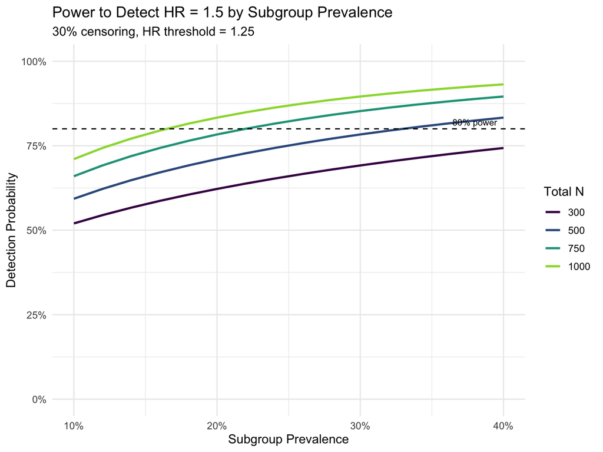

Detection power by subgroup prevalence for different trial sizes

```r
# Different total sample sizes
N_values <- c(300, 500, 750, 1000)
prevalence_seq <- seq(0.10, 0.40, by = 0.02)

power_by_prev <- expand.grid(
  N_total = N_values,
  prevalence = prevalence_seq
)

power_by_prev$n_sg <- power_by_prev$N_total * power_by_prev$prevalence
power_by_prev$probability <- sapply(power_by_prev$n_sg, function(n) {
  compute_detection_probability(
    theta = 1.5,
    n_sg = n,
    prop_cens = 0.30,
    hr_threshold = 1.25
  )
})

ggplot(power_by_prev, aes(x = prevalence, y = probability,
                          color = factor(N_total), group = N_total)) +
  geom_line(linewidth = 1) +
  geom_hline(yintercept = 0.80, linetype = "dashed") +
  scale_x_continuous(labels = scales::percent) +
  scale_y_continuous(labels = scales::percent, limits = c(0, 1)) +
  scale_color_viridis_d(option = "viridis", end = 0.85) +
  labs(
    x = "Subgroup Prevalence",
    y = "Detection Probability",
    color = "Total N",
    title = "Power to Detect HR = 1.5 by Subgroup Prevalence",
    subtitle = "30% censoring, HR threshold = 1.25"
  ) +
  annotate("text", x = 0.38, y = 0.82, label = "80% power", size = 3)
```

# 8 Quick Reference Tables

## 8.1 Standard Scenarios (HR Threshold = 1.25)

```r
ref_table_125 <- expand.grid(
  theta = c(1.3, 1.5, 1.75, 2.0),
  prop_cens = c(0.20, 0.30, 0.40),
  power = c(0.70, 0.80, 0.90)
)

ref_table_125$n_required <- mapply(function(th, pc, pw) {
  res <- find_required_sample_size(
    theta = th,
    target_power = pw,
    prop_cens = pc,
    hr_threshold = 1.25,
    verbose = FALSE
  )
  res$n_sg_required
}, ref_table_125$theta, ref_table_125$prop_cens, ref_table_125$power)

# Format for display
ref_wide <- dcast(
  as.data.table(ref_table_125),
  theta + prop_cens ~ power,
  value.var = "n_required"
)
names(ref_wide) <- c("True HR", "Censoring", "70% Power", "80% Power", "90% Power")
ref_wide$Censoring <- sprintf("%.0f%%", 100 * ref_wide$Censoring)

knitr::kable(ref_wide, align = "c")
```

Sample size reference table (HR threshold = 1.25)

| True HR | Censoring | 70% Power | 80% Power | 90% Power |
| --- | --- | --- | --- | --- |
| 1.30 | 20% | NA | NA | NA |
| 1.30 | 30% | NA | NA | NA |
| 1.30 | 40% | NA | NA | NA |
| 1.50 | 20% | 83 | 145 | 271 |
| 1.50 | 30% | 95 | 165 | 310 |
| 1.50 | 40% | 111 | 193 | 362 |
| 1.75 | 20% | 36 | 59 | 103 |
| 1.75 | 30% | 41 | 68 | 117 |
| 1.75 | 40% | 48 | 79 | 137 |
| 2.00 | 20% | 22 | 36 | 62 |
| 2.00 | 30% | 25 | 41 | 70 |
| 2.00 | 40% | 30 | 48 | 82 |

## 8.2 Conservative Scenarios (HR Threshold = 1.50)

```r
ref_table_150 <- expand.grid(
  theta = c(1.75, 2.0, 2.5, 3.0),
  prop_cens = c(0.20, 0.30, 0.40),
  power = c(0.70, 0.80, 0.90)
)

ref_table_150$n_required <- mapply(function(th, pc, pw) {
  res <- find_required_sample_size(
    theta = th,
    target_power = pw,
    prop_cens = pc,
    hr_threshold = 1.50,
    n_range = c(10, 800),
    verbose = FALSE
  )
  res$n_sg_required
}, ref_table_150$theta, ref_table_150$prop_cens, ref_table_150$power)

# Format for display
ref_wide_150 <- dcast(
  as.data.table(ref_table_150),
  theta + prop_cens ~ power,
  value.var = "n_required"
)
names(ref_wide_150) <- c("True HR", "Censoring", "70% Power", "80% Power", "90% Power")
ref_wide_150$Censoring <- sprintf("%.0f%%", 100 * ref_wide_150$Censoring)

knitr::kable(ref_wide_150, align = "c")
```

Sample size reference table (HR threshold = 1.50)

| True HR | Censoring | 70% Power | 80% Power | 90% Power |
| --- | --- | --- | --- | --- |
| 1.75 | 20% | NA | NA | NA |
| 1.75 | 30% | NA | NA | NA |
| 1.75 | 40% | NA | NA | NA |
| 2.00 | 20% | NA | NA | NA |
| 2.00 | 30% | NA | NA | NA |
| 2.00 | 40% | NA | NA | NA |
| 2.50 | 20% | NA | NA | NA |
| 2.50 | 30% | NA | NA | NA |
| 2.50 | 40% | NA | NA | NA |
| 3.00 | 20% | 10 | NA | NA |
| 3.00 | 30% | NA | NA | NA |
| 3.00 | 40% | 13 | 20 | 35 |

# 9 Limitations and Considerations

## 9.1 Assumptions

The asymptotic approximation assumes: 1. **Large samples:** The normal approximation for log(HR) requires sufficient events 2. **Proportional hazards:** The Cox model assumption holds 3. **Independent splits:** The two split-halves are conditionally independent 4. **Known censoring:** Censoring proportion is accurately estimated

## 9.2 When Approximations May Fail

```r
# Check where approximation breaks down
small_n_probs <- sapply(c(10, 20, 30, 40, 50), function(n) {
  compute_detection_probability(
    theta = 1.5,
    n_sg = n,
    prop_cens = 0.30,
    hr_threshold = 1.25
  )
})

cat("Detection probability by small sample sizes:\n")
```

```
Detection probability by small sample sizes:
```

```r
cat(sprintf("  n = %2d: %.3f\n", c(10, 20, 30, 40, 50), small_n_probs))
```

```
  n = 10: 0.407
   n = 20: 0.472
   n = 30: 0.520
   n = 40: 0.560
   n = 50: 0.593
```

```r
cat("\nNote: For n < 30, asymptotic approximations may be unreliable.\n")
```

```
Note: For n < 30, asymptotic approximations may be unreliable.
```

```r
cat("Consider simulation-based power analysis for small subgroups.\n")
```

```
Consider simulation-based power analysis for small subgroups.
```

## 9.3 Practical Recommendations

1. **Minimum subgroup size:** Aim for n ≥ 40-60 for reliable asymptotic results
2. **Event requirement:** Ensure ≥ 20-30 events in the subgroup
3. **Validation:** For critical decisions, validate with simulation studies
4. **Multiple testing:** Account for multiplicity when analyzing many subgroups

# 11 References

1. León LF, Marceau-West CT, He W, et al. (2024). “Identifying Patient Subgroups with Differential Treatment Effects: A Forest Search Approach.” *Statistics in Medicine*.
2. Athey S, Imbens GW. (2016). “Recursive partitioning for heterogeneous causal effects.” *PNAS*, 113(27):7353-7360.
3. Wager S, Athey S. (2018). “Estimation and inference of heterogeneous treatment effects using random forests.” *JASA*, 113(523):1228-1242.